# Homework 3

Diana Rueda

5/9/2020

### Multiple linear regression

1. Run the following code to create the vectors x1, x2, and y.

```r
set.seed(1)
n <- 100
x1 <- runif(n)
x2 <- runif(n,10,20)
e = rnorm(n)
y <- 2 + 2 * x1 + 0.3 * x2 + e
```

1. (2 pts) The last line of the code above corresponds to creating a linear model in which y is a function of x1 and x2. Write out the form of the linear model. What are the values of the regression coefficients β0, β1 and β2? What is the value of σ2?

```r
#The linear model is:
# Y = 2 + 2X_1 + 0.3 X_2 + e
# where β0 = 2, β1 = 2, β2 = 0.3, and σ^2 = (||e||^2_2) / (n-p-1).
X <- cbind(rep(1,100), x1, x2)
beta_hats <- c(2, 2, 0.3)
norm_e <- sqrt(sum(e^2))
sigma2 <- (norm_e ^2) / (n - 2 - 1)
sigma2
```

```
## [1] 0.9379242
```

2. (2 pts) What is the correlation coefficient between x1 and x2? Create a scatter plot using ggplot2 displaying the relationship between the variables x1 and x2.

```r
r_2 <- cor(x1, x2)
r_2
```

```
## [1] 0.01703215
```

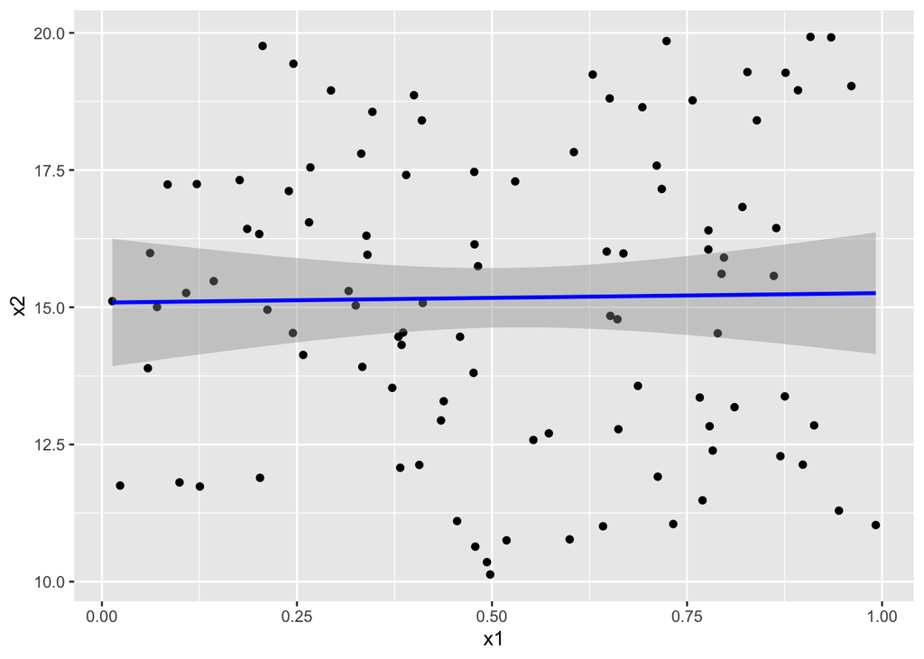

```r
library("ggplot2")
ggplot(data = as.data.frame(X)) +
    geom_point(mapping = aes(x = x1, y = x2)) +
  geom_smooth(mapping = aes(x = x1, y = x2), method = "lm", color = "blue")
```

3. (4 pts) Fit a least squares regression to predict y using x1 and x2. Describe the obtained results. What are the values of β̂ 0, β̂ 1 and β̂ 2? How do these relate to the true values of β0, β1 and β2? What is the value of s and how does it relate to the true value of σ2? Can you reject the null hypothesis H0:β1=0? How about the null hypothesis H0:β2=0?

```r
model <- lm(y ~ x1 + x2, data = as.data.frame(X))
summary(model)
```

```
##
## Call:
## lm(formula = y ~ x1 + x2, data = as.data.frame(X))
##
## Residuals:
##     Min      1Q  Median      3Q     Max
## -1.8579 -0.6167 -0.1432  0.5352  2.3318
##
## Coefficients:
##             Estimate Std. Error t value Pr(>|t|)
## (Intercept)  1.97628    0.57973   3.409 0.000951 ***
## x1           1.93074    0.36345   5.312 6.89e-07 ***
## x2           0.30144    0.03578   8.425 3.33e-13 ***
## ---
## Signif. codes:  0 '***' 0.001 '**' 0.01 '*' 0.05 '.' 0.1 ' ' 1
##
## Residual standard error: 0.9675 on 97 degrees of freedom
## Multiple R-squared:  0.5095, Adjusted R-squared:  0.4994
## F-statistic: 50.38 on 2 and 97 DF,  p-value: 9.917e-16
```

The values of the beta 0,1, and 2 hat are indicated under the column marked as estimates in that order.

The obtained results are very close to the values used in the initial y model. We should note that the estimates for the intercept and beta 1 are lower than the initial model while the estimate for beta 2 is slightly higher. As the table indicates both x1 and x2 are significant.

However the r square coefficient increased significantly.

In addition the value of s = 0.9675 increased by a very small amount as compared to the initial model where sigma squared was 0.9379.

We can reject both null hypothesis H0:β1=0 and H0:β2=0 since even after considering the possible variation of the estimates (standard error) there is enough evidence (t- value and F-stat) to suggest that beta1 and beta2 are not zero and therefore have a significant influence in the model.

4. (3 pts) Now fit a least squares regression to predict y using only x1. Comment on your results. What are the values of β̂ 0 and β̂ 1? How do these relate to the true values of β0 and β1? What is the value of s and how does it relate to the true value of σ2? Can you reject the null hypothesis H0:β1=0?

```r
model2 <- lm(data = as.data.frame(X), y ~ x1)
summary(model2)
```

```
##
## Call:
## lm(formula = y ~ x1, data = as.data.frame(X))
##
## Residuals:
##      Min       1Q   Median       3Q      Max
## -2.48228 -0.97125 -0.03059  0.93666  2.78169
##
## Coefficients:
##             Estimate Std. Error t value Pr(>|t|)
## (Intercept)   6.5235     0.2770  23.548  < 2e-16 ***
## x1            1.9829     0.4758   4.168 6.64e-05 ***
## ---
## Signif. codes:  0 '***' 0.001 '**' 0.01 '*' 0.05 '.' 0.1 ' ' 1
##
## Residual standard error: 1.267 on 98 degrees of freedom
## Multiple R-squared:  0.1506, Adjusted R-squared:  0.1419
## F-statistic: 17.37 on 1 and 98 DF,  p-value: 6.638e-05
```

In this model the value of beta0 increased to 6.5235 with a lower standard error of 0.2770 and a better significance of less than 2e-16, while the value of beta1 increased from 1.93074 to 1.9829 with a standard error of 0.4758 which is a little higher than in the previous model as is its significance.

Compared to the true values of beta0 and beta1, the estimates of this model are less accurate than those in the first least squares model. Beta0 is over 6 while the true value is 2 and beta 1 is 1.9829 while the true value is 2 as well.

In addition if we look at the r-squared and adjusted r-square we can confirm that this model containing only x1 is less accurate than the model containing x1 and x2. These values degreased significantly after removing one variable.

In this model s = 1.267 which is higher in comparison with the sigma squared of the initial model.

Based on the information given we can reject the null hypothesis H0:β1=0. The estimator is further away from zero and the standard error is small enough that even then it would not be zero. In addition to this the t-stat has a high significance level indicating that beta1 is not zero.

5. (3 pts) Now fit a least squares regression to predict y using only x2. Comment on your results. What are the values of β̂ 0 and β̂ 2? How do these relate to the true values of β0 and β2? What is the value of s and does it relate to the true value of σ2? Can you reject the null hypothesis H0:β2=0?

```r
model3 <- lm(data = as.data.frame(X), y ~ x2)
summary(model3)
```

```
##
## Call:
## lm(formula = y ~ x2, data = as.data.frame(X))
##
## Residuals:
##     Min      1Q  Median      3Q     Max
## -2.3432 -0.8776 -0.1927  0.7798  2.5804
##
## Coefficients:
##             Estimate Std. Error t value Pr(>|t|)
## (Intercept)  2.92698    0.62330   4.696 8.64e-06 ***
## x2           0.30467    0.04044   7.534 2.46e-11 ***
## ---
## Signif. codes:  0 '***' 0.001 '**' 0.01 '*' 0.05 '.' 0.1 ' ' 1
##
## Residual standard error: 1.094 on 98 degrees of freedom
## Multiple R-squared:  0.3668, Adjusted R-squared:  0.3603
## F-statistic: 56.77 on 1 and 98 DF,  p-value: 2.465e-11
```

In this model the values of beta0 and beta2 are closer to the actual values than the estimates in the previous model. Beta0 is further away from the true value than it was in the model containing both x1 and x2 but not as further away as in the model containing only x1.

The value of s is now 1.094 which is higher than the true value of sigma squared and lower than the value of s in the model containing only x1.

Based on this information and the test statistics we can reject the null hypothesis H0:β2=0 . Its t value shows high significance, and the estimator is far enough from zero with a small enough standard error that indicate beta2 is not zero.

2. Run the following code to create the vectors x1, x2, and y.

```r
set.seed(1)
n <- 100
x1 <- runif(n)
x2 <- 0.5 * x1 + rnorm(n,0,.01)
e <- rnorm(n)
y <- 2 + 2 * x1 + 0.3 * x2 + e
```

1. (8 pts) Repeat parts b, c, d, and e of Exercise 1 using the new vectors x1, x2 and y. What differences do you see between Exercise 1 and Exercise 2? Explain why these differences occur.

*b) What is the correlation coefficient between x1 and x2? Create a scatter plot using ggplot2 displaying the relationship between the variables x1 and x2.*

```r
X <- cbind(rep(1,100), x1, x2)
norm_e <- sqrt(sum(e^2))
sigma2 <- (norm_e ^2) / (n - 2 - 1)
sigma2
```

```
## [1] 1.123012
```

```r
r_2 <- cor(x1, x2)
r_2
```

```
## [1] 0.9975904
```

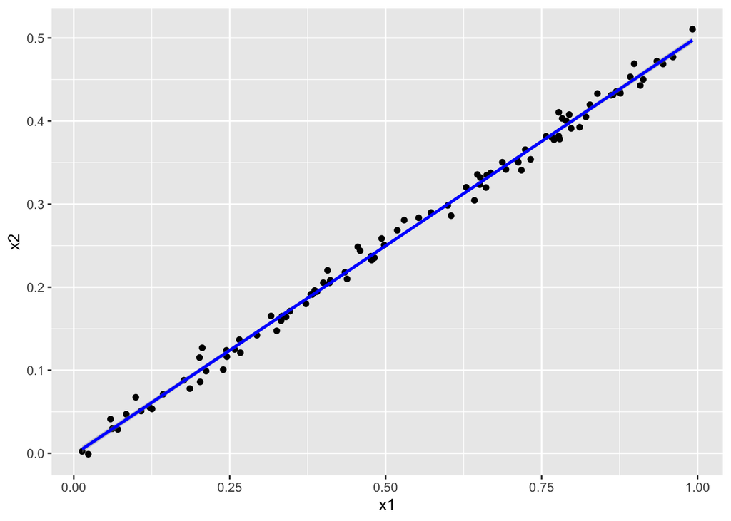

```r
ggplot(data = as.data.frame(X)) +
    geom_point(mapping = aes(x = x1, y = x2)) +
  geom_smooth(mapping = aes(x = x1, y = x2), method = "lm", color = "blue")
```

The sigma squared value for this model is 1.123012 while the correlation coefficient is 0.99759 which is explained by the fact that we used x1 to generate the values for x2 in the previous question.

*c) Fit a least squares regression to predict y using x1 and x2. Describe the obtained results. What are the values of β̂ 0, β̂ 1 and β̂ 2? How do these relate to the true values of β0, β1 and β2? What is the value of s and how does it relate to the true value of σ2? Can you reject the null hypothesis H0:β1=0? How about the null hypothesis H0:β2=0?*

```r
model4 <- lm(y ~ x1 + x2, data = as.data.frame(X))
summary(model4)
```

```
##
## Call:
## lm(formula = y ~ x1 + x2, data = as.data.frame(X))
##
## Residuals:
##     Min      1Q  Median      3Q     Max
## -2.8311 -0.7273 -0.0537  0.6338  2.3359
##
## Coefficients:
##             Estimate Std. Error t value Pr(>|t|)
## (Intercept)   2.1305     0.2319   9.188 7.61e-15 ***
## x1           -1.7540     5.7178  -0.307    0.760
## x2            7.3967    11.3372   0.652    0.516
## ---
## Signif. codes:  0 '***' 0.001 '**' 0.01 '*' 0.05 '.' 0.1 ' ' 1
##
## Residual standard error: 1.056 on 97 degrees of freedom
## Multiple R-squared:  0.2051, Adjusted R-squared:  0.1887
## F-statistic: 12.51 on 2 and 97 DF,  p-value: 1.465e-05
```

The estimate for beta0 is 2.1305 with standard error 0.2319 and this is the only estimate whose t-value is significant and which is close to its true value. The estimates for beta1 and beta2 are largely different from their true values and contain a high standard error for their magnitude. Thus their t- values are not significant.

The value of s in this model is 1.056 which is slightly lower than sigma squared of the original model.

Based on the information for beta1 we do not have enough data suggesting that we should reject the null hypothesis H0:β1=0.

Based on the information for beta2 we do not have enough data suggesting that we should reject the null hypothesis H0:β2=0.

*d) Now fit a least squares regression to predict y using only x1. Comment on your results. What are the values of β̂ 0 and β̂ 1? How do these relate to the true values of β0 and β1? What is the value of s and how does it relate to the true value of σ2? Can you reject the null hypothesis H0:β1=0?*

```r
model5 <- lm(data = as.data.frame(X), y ~ x1)
summary(model5)
```

```
##
## Call:
## lm(formula = y ~ x1, data = as.data.frame(X))
##
## Residuals:
##      Min       1Q   Median       3Q      Max
## -2.87789 -0.68357 -0.07517  0.61429  2.40388
##
## Coefficients:
##             Estimate Std. Error t value Pr(>|t|)
## (Intercept)   2.1172     0.2303   9.193 6.83e-15 ***
## x1            1.9675     0.3955   4.974 2.79e-06 ***
## ---
## Signif. codes:  0 '***' 0.001 '**' 0.01 '*' 0.05 '.' 0.1 ' ' 1
##
## Residual standard error: 1.053 on 98 degrees of freedom
## Multiple R-squared:  0.2016, Adjusted R-squared:  0.1934
## F-statistic: 24.74 on 1 and 98 DF,  p-value: 2.795e-06
```

This model is closer to the true values of beta0 and beta1 in comparison with the last model where we include x2 which depends on x1.

The values for beta0 and beta1 are 2.1172 and 1.9675 respectively. They are both close enough to the true values of these parameters that the standard errors and t values allow them to aline with the true values. Both parameters are highly significant in this model.

The s = 1.053 is slightly lower than the true value of sigma squared calculated above at sigma-squared = 1.1230. In addition the adjusted r-squared increases as compared to the previous model.

Based on the information above we can reject the null hypothesis H0:β1=0, our estimate, its error, its t-value and significance indicate that beta1 is not zero.

*e) Now fit a least squares regression to predict y using only x2. Comment on your results. What are the values of β̂ 0 and β̂ 2? How do these relate to the true values of β0 and β2? What is the value of s and does it relate to the true value of σ2? Can you reject the null hypothesis H0:β2=0?*

```r
model6 <- lm(data = as.data.frame(X), y ~ x2)
summary(model6)
```

```
##
## Call:
## lm(formula = y ~ x2, data = as.data.frame(X))
##
## Residuals:
##      Min       1Q   Median       3Q      Max
## -2.85470 -0.68465 -0.06898  0.60983  2.34499
##
## Coefficients:
##             Estimate Std. Error t value Pr(>|t|)
## (Intercept)   2.1199     0.2282   9.288 4.24e-15 ***
## x2            3.9273     0.7829   5.016 2.35e-06 ***
## ---
## Signif. codes:  0 '***' 0.001 '**' 0.01 '*' 0.05 '.' 0.1 ' ' 1
##
## Residual standard error: 1.051 on 98 degrees of freedom
## Multiple R-squared:  0.2043, Adjusted R-squared:  0.1962
## F-statistic: 25.16 on 1 and 98 DF,  p-value: 2.35e-06
```

The estimate for beta2 = 3.9273 is considerably higher than its true value of 0.3, while beta0 = 2.1199 remains close to its true value of 2. In this model both estimators are significant according to t-values and standard error.

Given the information above we can reject the null hypothesis H0:β2=0. our estimate, its error, its t-value and significance indicate that beta2 is not zero even though beta2 overestimates the value of the true parameter.

3. Use x1, x2 and y from Exercise 2 and suppose that we obtain one additional observation, which was unfortunately mismeasured.

```r
x1 <- c(x1, 0.1)
x2 <- c(x2, 0.8)
y <- c(y, 6)

X <- cbind(rep(1,101), x1, x2)
```

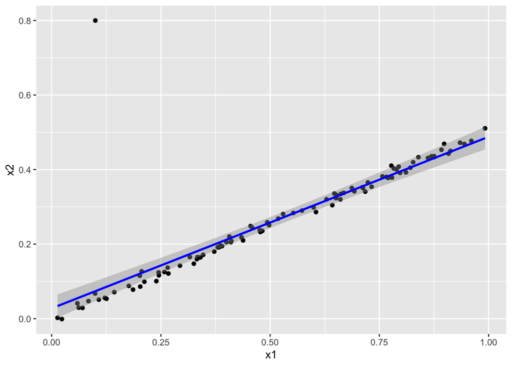

```r
ggplot(data = as.data.frame(X)) +
    geom_point(mapping = aes(x = x1, y = x2)) +
  geom_smooth(mapping = aes(x = x1, y = x2), method = "lm", color = "blue")
```

1. (8 pts) Re-fit the linear models from parts c, d and e of Exercise 1 using this new data. What effect does this new observation have on the each of the models? In each model, is this observation an outlier? A high-leverage point? Both? Explain your answers.

```r
model7 <- lm(y ~ x1 + x2, data = as.data.frame(X))
summary(model7)
```

```
##
## Call:
## lm(formula = y ~ x1 + x2, data = as.data.frame(X))
##
## Residuals:
##      Min       1Q   Median       3Q      Max
## -2.84668 -0.67731 -0.05031  0.58942  2.34440
##
## Coefficients:
##             Estimate Std. Error t value Pr(>|t|)
## (Intercept)   2.1250     0.2294   9.265 4.77e-15 ***
## x1           -0.5183     0.7578  -0.684 0.495630
## x2            4.9440     1.4114   3.503 0.000695 ***
## ---
## Signif. codes:  0 '***' 0.001 '**' 0.01 '*' 0.05 '.' 0.1 ' ' 1
##
## Residual standard error: 1.051 on 98 degrees of freedom
## Multiple R-squared:  0.2495, Adjusted R-squared:  0.2341
## F-statistic: 16.29 on 2 and 98 DF,  p-value: 7.82e-07
```

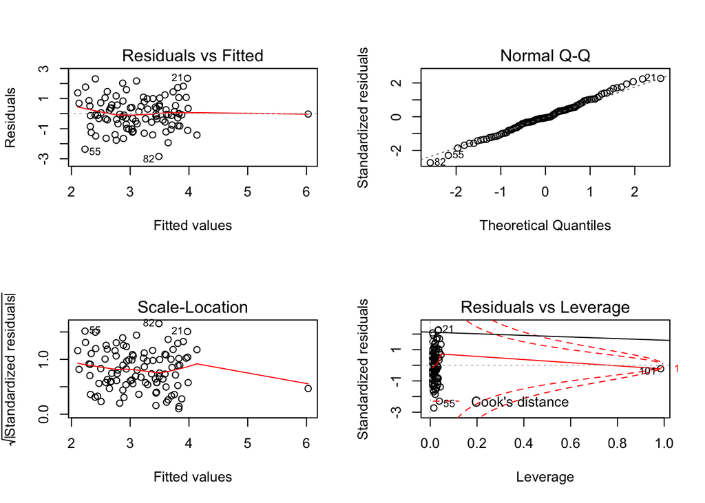

```r
par(mfrow = c(2,2))
plot(model7)
abline(model7)
```

```r
H_model7 = X %*% solve(t(X) %*% X) %*% t(X)
H_model7[101,101] #laverage statistic for model7
```

```
## [1] 0.9848723
```

```r
# greatly exceeds (p+1)/n so it is a high laverage point
```

*Explanation:*  
This observation is a high laverage point based on the plot of residuals vs laverage and on the value of the ith diagonal entry (0.9849) of the matrix H. The laverage of this observation greatly exceeds (p+1)/n for this model.

Based on the model and residual plots above this observation is not considered an outlier for this model. It’s y value can be exlained and falls within the distribution of the model.

```r
model8 <- lm(data = as.data.frame(X), y ~ x1)
summary(model8)
```

```
##
## Call:
## lm(formula = y ~ x1, data = as.data.frame(X))
##
## Residuals:
##     Min      1Q  Median      3Q     Max
## -2.8726 -0.6826 -0.0747  0.5774  3.5626
##
## Coefficients:
##             Estimate Std. Error t value Pr(>|t|)
## (Intercept)   2.2616     0.2385   9.481 1.48e-15 ***
## x1            1.7575     0.4116   4.270 4.50e-05 ***
## ---
## Signif. codes:  0 '***' 0.001 '**' 0.01 '*' 0.05 '.' 0.1 ' ' 1
##
## Residual standard error: 1.109 on 99 degrees of freedom
## Multiple R-squared:  0.1555, Adjusted R-squared:  0.147
## F-statistic: 18.23 on 1 and 99 DF,  p-value: 4.498e-05
```

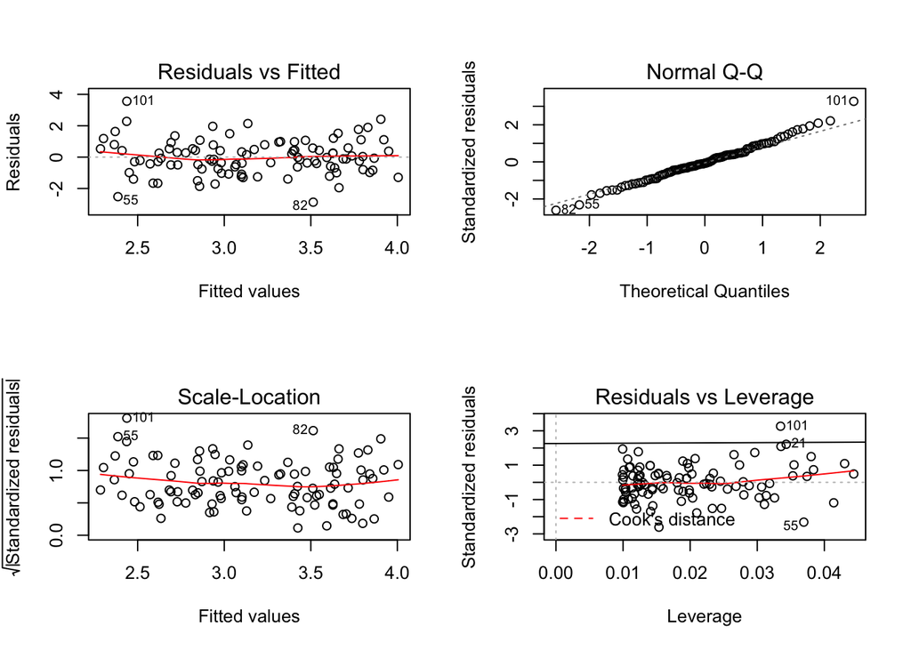

```r
par(mfrow = c(2,2))
plot(model8)
abline(model8)
```

```r
X_x1 <- X[,1:2]
H_model8 = X_x1 %*% solve(t(X_x1) %*% X_x1) %*% t(X_x1)
H_model8[101,101]
```

```
## [1] 0.03347156
```

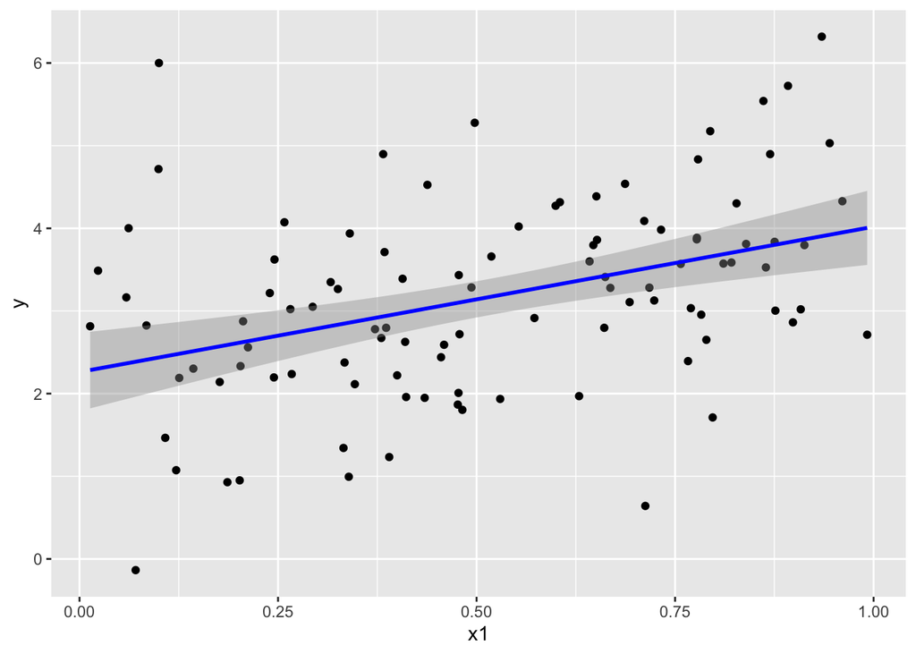

```r
ggplot(as.data.frame(X), aes(x = x1, y = y)) + geom_point() + geom_smooth(method = "lm", col = "blue")
```

Based on the plot of the regression line we can see that the point is far from the line which indicates we should consider this observation an outlier. This can be confirmed with the help of the residual plots which indicate that observation 101 is indeed an outlier.

```r
model9 <- lm(data = as.data.frame(X), y ~ x2)
summary(model9)
```

```
##
## Call:
## lm(formula = y ~ x2, data = as.data.frame(X))
##
## Residuals:
##      Min       1Q   Median       3Q      Max
## -2.87832 -0.66757 -0.06731  0.62962  2.36205
##
## Coefficients:
##             Estimate Std. Error t value Pr(>|t|)
## (Intercept)   2.0773     0.2179   9.532 1.15e-15 ***
## x2            4.1164     0.7245   5.681 1.34e-07 ***
## ---
## Signif. codes:  0 '***' 0.001 '**' 0.01 '*' 0.05 '.' 0.1 ' ' 1
##
## Residual standard error: 1.048 on 99 degrees of freedom
## Multiple R-squared:  0.2459, Adjusted R-squared:  0.2383
## F-statistic: 32.28 on 1 and 99 DF,  p-value: 1.345e-07
```

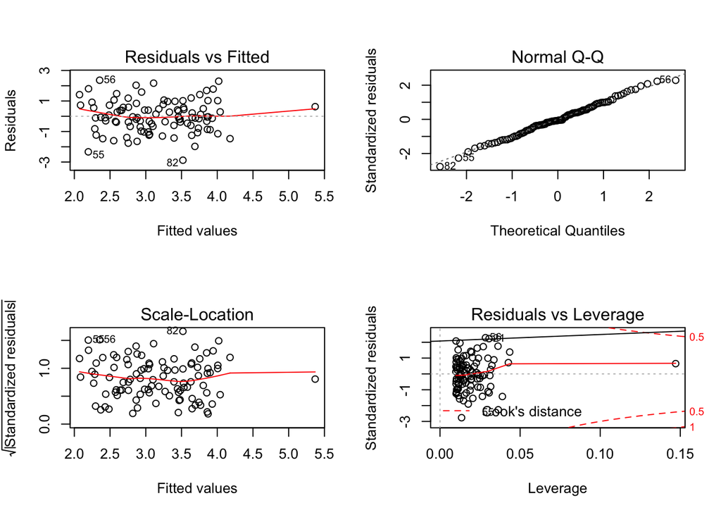

```r
par(mfrow = c(2,2))
plot(model9)
abline(model9)
```

```r
X_x2 <- X[,c(1,3)]
H_model9 = X_x2 %*% solve(t(X_x2) %*% X_x2) %*% t(X_x2)
H_model9[101,101]
```

```
## [1] 0.1471062
```

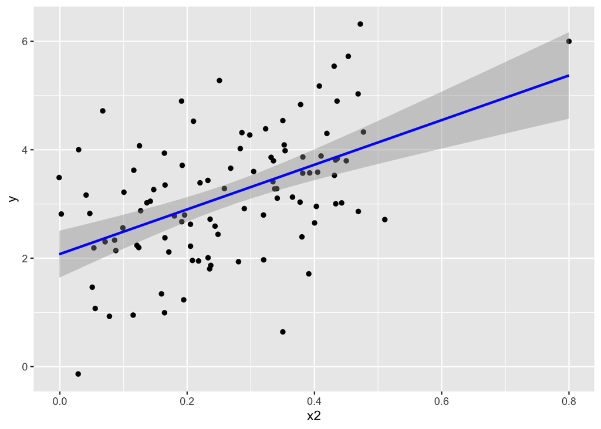

```r
ggplot(as.data.frame(X), aes(x = x2, y = y)) + geom_point() + geom_smooth(method = "lm", col = "blue")
```

*Observations*  
The addition of observation 101 increased the values for r-squared, adjusted r-squared and the F-stat. The difference in the residual standard error is lower than in other models. The estimate for beta2 increased while its standard error remained very close to the previous model as well as its significance. The estimator for beta1 decreased getting closer to the true value of this parameter, and both betas remain significant.

This observation is not an outlier based on the model and plots provided. The high y value can be explained by the linear regression that this model represents.